# Predicting_Loan_Status

[Portfolio](https://mbguel.github.io)

#### Miguel Bautista

This project was completed through my education at General Assembly. My assignment was to predict whether or not a person should be approved for a loan based on a variety of factors.

## Predict Loan Funding

This challenge is a standard supervised learning problem. The dataset includes application data for every loan given over a 6 month period.

There are 4 tabs with data, labeled **"trainX"**, **"trainY"**, **"testX"** and **"testY"**. The train tabs contain the first 4.5 months of loans, while the test tabs have loan data from the following 1.5 months.

**trainY** and **testY** contain the targets. They represent whether the loans were fully funded (TRUE values) or partially funded (FALSE values). The fully funded values are withheld from **testY**, and your job will be to **fill them in**.

Use **trainX** and **trainY** to build a model to predict whether or not future loans will be fully funded. You should then use your model on the data from testX to make new predictions. We’ll score those predictions against the true values of testY to see how well your model performs.

This is intended to be a fairly straightforward task. I didn’t intentionally include any big surprises or “gotchas”. I hope that your model performs well, but it’s even more important that your approach is sound and you avoid major mistakes.

Please put your predictions in column B of the "testY" tab. The predictions should be made such that higher values are more likely to be TRUE and lower values more likely FALSE.

Pleae include a short description of which evaluation metric you selected & why.

[Here's the dataset](https://render.githubusercontent.com/datasets/hw3/HW3Data.xlsx)

**Data Dictionary**

| Variable | Definition | Type |
| --- | --- | --- |
| customer_id | unique customer id | alphanumeric |
| status | was customer approved or denied | String |
| residence_rent_or_own | customer is renting | Boolean |
| monthly_rent_amount | monthly rent amount | Numeric |
| bank_account_direct_deposit | customer signed up for direct deposit | Boolean |
| application_when | date when customer applied for a loan | MM/DD/YY HH:MM |
| loan_duration | term of loan | Numeric |
| payment_ach | has customer signed up for ACH payments | Boolean |
| num_payments | # of payments made by customer | Numeric |
| address_zip | customer resident zip code | Numeric |
| bank_routing_number | customer bank routing number | Numeric |
| home_phone_type | type of customer phone | String |
| monthly_income_amount | customer monthly income amount | Numeric |
| raw_l2c_score | Third party score | Numeric |
| raw_FICO_telecom | Third party score | Numeric |
| raw_FICO_retail | Third party score | Numeric |
| raw_FICO_bank_card | Third party score | Numeric |
| raw_FICO_money | Third party score | Numeric |
| FullyFunded | Fund customer | Boolean |

Good luck!

```python
import pandas as pd
import numpy as np
import seaborn as sns
import matplotlib.pyplot as plt


import random
from sklearn.metrics import roc_curve, auc
from sklearn.model_selection import cross_val_score
from sklearn.model_selection import KFold
from sklearn.model_selection import GridSearchCV


# Importing the various models

from sklearn.tree import DecisionTreeClassifier
from sklearn.ensemble import RandomForestClassifier
from sklearn.linear_model import LogisticRegression
from sklearn.linear_model import Lasso, Ridge
from sklearn.neighbors import KNeighborsClassifier
from sklearn.ensemble import GradientBoostingClassifier
import xgboost as xgb
from sklearn.svm import SVC

# Ensemble model
from sklearn.ensemble import VotingClassifier


# Import sklearn
from sklearn import feature_selection, linear_model
import warnings
warnings.filterwarnings('ignore')

%matplotlib inline
```

#### Loading train and test data.

```python
sheets = ['trainX','trainY','testX','testY']

trainX = pd.read_excel("HW3Data.xlsx", sheetname='trainX')
trainY = pd.read_excel("HW3Data.xlsx", sheetname='trainY')
testX = pd.read_excel("HW3Data.xlsx", sheetname='testX')
testY = pd.read_excel("HW3Data.xlsx", sheetname='testY')

trainX.head()
```

|  | customer_id | status | residence_rent_or_own | monthly_rent_amount | bank_account_direct_deposit | application_when | loan_duration | payment_ach | num_payments | address_zip | bank_routing_number | home_phone_type | monthly_income_amount | raw_l2c_score | raw_FICO_telecom | raw_FICO_retail | raw_FICO_bank_card | raw_FICO_money |
| --- | --- | --- | --- | --- | --- | --- | --- | --- | --- | --- | --- | --- | --- | --- | --- | --- | --- | --- |
| 0 | 9ece67d6c5 | Approved | True | 0 | True | 2010-10-16 14:06:00 | 3 | True | 6 | 84118 | 124001545 | Mobile | 1560 | 614 | 574 | 600 | 656 | 561 |
| 1 | 5c2c402094 | Approved | True | 0 | False | 2010-10-17 13:01:00 | 6 | True | 13 | 84062 | 124000054 | Mobile | 900 | 708 | 501 | 550 | 651 | 563 |
| 2 | e6254cad30 | Approved | True | 620 | True | 2010-10-17 19:52:00 | 6 | True | 13 | 84119 | 124001545 | Mobile | 1434 | 687 | 522 | 561 | 661 | 598 |
| 3 | 49fb42f51d | Approved | False | 785 | False | 2010-10-18 07:05:00 | 4 | True | 8 | 84405 | 124002971 | Mobile | 1600 | 616 | 560 | 552 | 634 | 591 |
| 4 | 195fbe5739 | Approved | True | 700 | True | 2010-10-19 10:58:00 | 4 | True | 8 | 84404 | 124002971 | Mobile | 1360 | 681 | 603 | 654 | 659 | 636 |

```python
trainY.head()
```

|  | customer_id | FullyFunded |
| --- | --- | --- |
| 0 | 9ece67d6c5 | True |
| 1 | 5c2c402094 | True |
| 2 | e6254cad30 | True |
| 3 | 49fb42f51d | True |
| 4 | 195fbe5739 | True |

```python
trainX.shape
print("Dataset shape: {}, {}".format(trainX.shape[0], trainX.shape[1]))
```

```
Dataset shape: 400, 18
```

```python
# Info about data set, datatype
trainX.info()
```

```
<class 'pandas.core.frame.DataFrame'>
RangeIndex: 400 entries, 0 to 399
Data columns (total 18 columns):
customer_id                    400 non-null object
status                         400 non-null object
residence_rent_or_own          400 non-null bool
monthly_rent_amount            400 non-null int64
bank_account_direct_deposit    400 non-null bool
application_when               400 non-null datetime64[ns]
loan_duration                  400 non-null int64
payment_ach                    400 non-null bool
num_payments                   400 non-null int64
address_zip                    400 non-null int64
bank_routing_number            400 non-null int64
home_phone_type                400 non-null object
monthly_income_amount          400 non-null int64
raw_l2c_score                  400 non-null int64
raw_FICO_telecom               400 non-null int64
raw_FICO_retail                400 non-null int64
raw_FICO_bank_card             400 non-null int64
raw_FICO_money                 400 non-null int64
dtypes: bool(3), datetime64[ns](1), int64(11), object(3)
memory usage: 48.1+ KB
```

```python
# Checking for missing values
trainX.isnull().sum()
```

```
customer_id                    0
status                         0
residence_rent_or_own          0
monthly_rent_amount            0
bank_account_direct_deposit    0
application_when               0
loan_duration                  0
payment_ach                    0
num_payments                   0
address_zip                    0
bank_routing_number            0
home_phone_type                0
monthly_income_amount          0
raw_l2c_score                  0
raw_FICO_telecom               0
raw_FICO_retail                0
raw_FICO_bank_card             0
raw_FICO_money                 0
dtype: int64
```

Turns out to be no missing values, so no need to impute data.

```python
# Check customer id is same for features & target
print("Is customer ID same for feature & target? (training)", (pd.Series.equals(trainX.customer_id, trainY.customer_id)))
print("Is customer ID same for feature & target? (test)", (pd.Series.equals(testX.customer_id, testY.customer_id)))

# Check if columns are the same/same order
trainX.columns == testX.columns
```

```
Is customer ID same for feature & target? (training) True
Is customer ID same for feature & target? (test) True
```

```
array([ True,  True,  True,  True,  True,  True,  True,  True,  True,
        True,  True,  True,  True,  True,  True,  True,  True,  True], dtype=bool)
```

```python
# Checking for any quirks
trainX.describe()
```

|  | monthly_rent_amount | loan_duration | num_payments | address_zip | bank_routing_number | monthly_income_amount | raw_l2c_score | raw_FICO_telecom | raw_FICO_retail | raw_FICO_bank_card | raw_FICO_money |
| --- | --- | --- | --- | --- | --- | --- | --- | --- | --- | --- | --- |
| count | 400.000000 | 400.000000 | 400.000000 | 400.000000 | 4.000000e+02 | 400.000000 | 400.00000 | 400.000000 | 400.000000 | 400.000000 | 400.000000 |
| mean | 594.317500 | 5.860000 | 10.800000 | 82409.300000 | 1.815323e+08 | 2645.565000 | 606.55000 | 566.180000 | 592.242500 | 664.005000 | 602.565000 |
| std | 435.895893 | 1.511991 | 4.485007 | 6506.387121 | 9.981754e+07 | 1651.009577 | 108.37745 | 43.278519 | 51.673388 | 40.141042 | 30.989865 |
| min | 0.000000 | 2.000000 | 3.000000 | 57003.000000 | 1.240000e+04 | 300.000000 | 50.00000 | 222.000000 | 222.000000 | 222.000000 | 222.000000 |
| 25% | 250.000000 | 5.000000 | 8.000000 | 84010.000000 | 1.240001e+08 | 1557.500000 | 544.00000 | 535.000000 | 553.000000 | 648.000000 | 587.750000 |
| 50% | 577.500000 | 5.000000 | 10.000000 | 84084.000000 | 1.240030e+08 | 2397.000000 | 600.50000 | 566.000000 | 590.000000 | 671.000000 | 605.500000 |
| 75% | 873.750000 | 8.000000 | 13.000000 | 84120.000000 | 3.240796e+08 | 3200.000000 | 671.75000 | 593.250000 | 632.000000 | 680.000000 | 621.000000 |
| max | 2100.000000 | 8.000000 | 34.000000 | 84790.000000 | 5.113005e+08 | 19392.000000 | 808.00000 | 698.000000 | 756.000000 | 796.000000 | 662.000000 |

```python
# Number of categorical columns
print("Number of categorical columns:", len(trainX.describe(include=['object']).columns))
trainX.describe(include=['object', 'datetime64'])
```

```
Number of categorical columns: 3
```

|  | customer_id | status | application_when | home_phone_type |
| --- | --- | --- | --- | --- |
| count | 400 | 400 | 400 | 400 |
| unique | 400 | 1 | 398 | 3 |
| top | 24960509ce | Approved | 2011-03-01 12:48:00 | Mobile |
| freq | 1 | 400 | 2 | 334 |
| first | NaN | NaN | 2010-10-16 14:06:00 | NaN |
| last | NaN | NaN | 2011-03-01 14:34:00 | NaN |

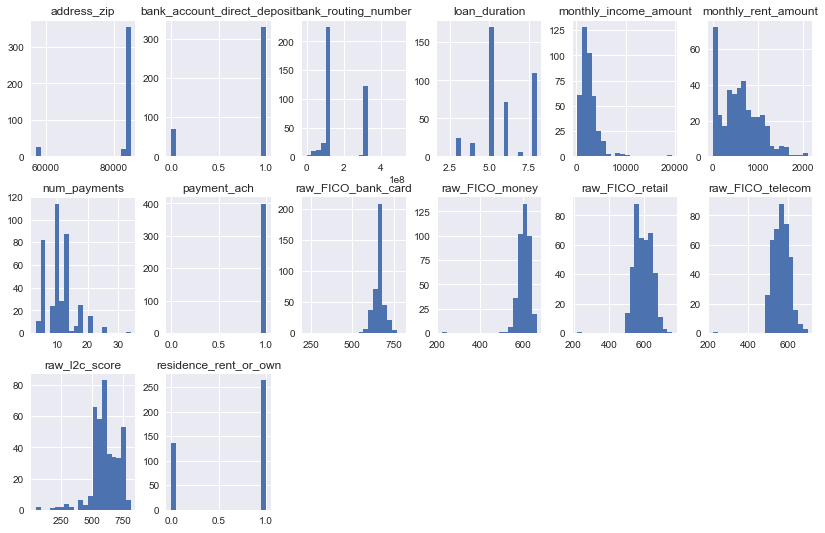

```python
# Plotting univariate distributions to check for skew, patterns, types of distribution
trainX.hist(layout = (3,6), figsize = (14,9), bins = 20);
```

Some graphs show a right skew (monthly_income_amount, monthly_rent_amount, num_payments). Others are categorical such as if someone rents or owns, or loan duration.

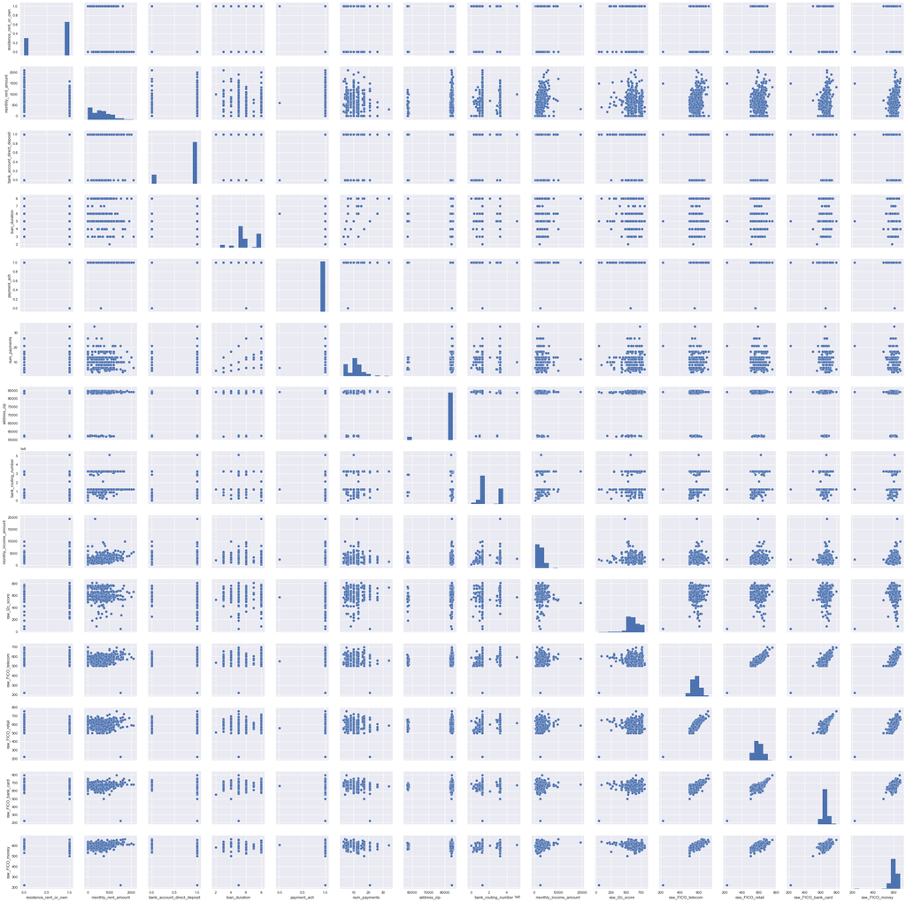

```python
sns.pairplot(trainX)
plt.show()
```

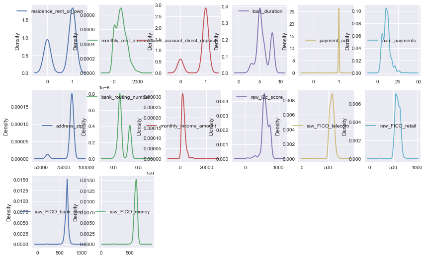

```python
trainX.plot(kind='density', subplots=True, layout=(3,6), figsize=(14,9), sharex=False);
```

```python
# Looking for skew
trainX.skew()
```

```
residence_rent_or_own          -0.678066
monthly_rent_amount             0.528339
bank_account_direct_deposit    -1.717120
loan_duration                   0.177955
payment_ach                   -20.000000
num_payments                    1.023847
address_zip                    -3.612955
bank_routing_number             0.701593
monthly_income_amount           3.640856
raw_l2c_score                  -1.149318
raw_FICO_telecom               -0.962150
raw_FICO_retail                -0.683382
raw_FICO_bank_card             -3.588302
raw_FICO_money                 -4.823780
dtype: float64
```

```python
# Checking when these applications were submitted, find the time range
trainX.application_when.sort_values()
```

```
0     2010-10-16 14:06:00
1     2010-10-17 13:01:00
2     2010-10-17 19:52:00
3     2010-10-18 07:05:00
4     2010-10-19 10:58:00
5     2010-10-21 21:21:00
6     2010-10-23 19:52:00
7     2010-10-24 16:05:00
8     2010-10-26 11:22:00
9     2010-10-27 14:12:00
10    2010-10-27 19:10:00
11    2010-10-28 07:50:00
12    2010-10-28 18:50:00
13    2010-10-30 11:53:00
14    2010-10-31 21:00:00
```

[output cut: 47 more lines]

```python
# Checking longest loan duration, appears to be 8 [years?] -- most common is 5 year loan
# trainX.loan_duration.sort_values(ascending=False)
trainX.loan_duration.value_counts()
```

```
5    170
8    110
6     71
3     24
4     18
7      6
2      1
Name: loan_duration, dtype: int64
```

#### Idea: Is it possible to add years (loan duration) to the date loan was applied for? Maybe to see if you can weigh number of payments strongly.

```python
# Checking address_zip, see if there is an imbalance in where these people live
trainX['address_zip'].value_counts()
```

```
84120    15
84118    13
84404    11
84119    10
84047    10
84067     9
84015     8
84123     8
84084     8
84010     8
84115     7
84088     7
84041     7
84660     6
84121     6
```

[output cut: 47 more lines]

Shows 146 different address_zip values.

```python
# Checking string and other variables.
print(trainX.status.value_counts())
print("******************")
trainX.bank_account_direct_deposit.value_counts()
```

```
Approved    400
Name: status, dtype: int64
******************
```

```
True     330
False     70
Name: bank_account_direct_deposit, dtype: int64
```

Noticed that all loans in trainX are approved. I checked with testX and it is also the same. There are more than 4 times the amount of people who use direct deposit than not.

### Checking for any correlations.

#### Example:

- See if monthly income has any correlation with FICO score
- Do number of payments correlate with FICO score?
- Does loan duration correlate with number of payments?

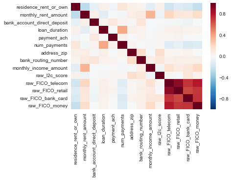

```python
corr = trainX.corr()
# plot correlation matrix
corr = trainX.corr()
sns.heatmap(corr,
           xticklabels=corr.columns.values,
           yticklabels=corr.columns.values);
```

There are a lot of highly correlated variables, particularly when it comes to the credit scores.

So maybe need to drop some of them?  
A possible approach would be to check their coefficients and p-values, and pick a FICO score.  
Note: Averaging would probably remove the differences, so I will not be doing that. (From Aug. 27 office hours)

#### Checking for "best" FICO score using the get_linear_model_metrics from the linear regression notebook.

```python
def get_linear_model_metrics(X, y, algo):
    # Get the pvalue of X given y. Ignore f-stat for now.
    pvals = feature_selection.f_regression(X, y)[1]
    # Start with an empty linear regression object
    # .fit() runs the linear regression function on X and y
    algo.fit(X,y)
    residuals = (y-algo.predict(X)).values

    # Print the necessary values
    print('P Values:', pvals)
    print('Coefficients:', algo.coef_)
    print('y-intercept:', algo.intercept_)
    print('R-Squared:', algo.score(X,y))

    # Plot residuals
#     h = sns.residplot(X,y)
#     h.set(xlabel="ah")

    # Keep the model
    return algo

# lm = get_linear_model_metrics(X, y, lm)


# The set of variables I will be checking coefficient, p-value, r-squared values:
x_sets = (
    ['raw_l2c_score'],
    ['raw_FICO_telecom'],
    ['raw_FICO_retail'],
    ['raw_FICO_bank_card'],
    ['raw_FICO_money'],
    ['raw_l2c_score', 'raw_FICO_telecom'],
    ['raw_l2c_score', 'raw_FICO_retail'],
    ['raw_l2c_score', 'raw_FICO_bank_card'],
    ['raw_l2c_score', 'raw_FICO_money'],
    ['raw_FICO_money','raw_FICO_bank_card']
)

# Using logistic regression as the linear model
for x in x_sets:
    print(', '.join(x))
    get_linear_model_metrics(trainX[x], trainY.FullyFunded, linear_model.LogisticRegression())
    print()
```

```
raw_l2c_score
P Values: [ 0.00570359]
Coefficients: [[ 0.00216036]]
y-intercept: [-0.29147695]
R-Squared: 0.73

raw_FICO_telecom
P Values: [ 0.00297036]
Coefficients: [[ 0.00364486]]
y-intercept: [-1.05015373]
R-Squared: 0.7325

raw_FICO_retail
P Values: [ 0.06799307]
Coefficients: [[ 0.00169972]]
y-intercept: [  2.77129940e-06]
R-Squared: 0.73

raw_FICO_bank_card
P Values: [ 0.01775891]
Coefficients: [[ 0.00151773]]
y-intercept: [  2.20145093e-06]
R-Squared: 0.73

raw_FICO_money
P Values: [ 0.00098666]
Coefficients: [[ 0.00167863]]
y-intercept: [  2.65596142e-06]
R-Squared: 0.73

raw_l2c_score, raw_FICO_telecom
P Values: [ 0.00570359  0.00297036]
Coefficients: [[ 0.0015589   0.00018553]]
y-intercept: [-0.02477229]
R-Squared: 0.73

raw_l2c_score, raw_FICO_retail
P Values: [ 0.00570359  0.06799307]
Coefficients: [[ 0.00184632 -0.00016244]]
y-intercept: [-0.00130779]
R-Squared: 0.73

raw_l2c_score, raw_FICO_bank_card
P Values: [ 0.00570359  0.01775891]
Coefficients: [[ 0.00205132 -0.00033713]]
y-intercept: [ -3.90915802e-06]
R-Squared: 0.7275

raw_l2c_score, raw_FICO_money
P Values: [ 0.00570359  0.00098666]
Coefficients: [[ 0.00185728 -0.0001708 ]]
y-intercept: [-0.00131104]
R-Squared: 0.73

raw_FICO_money, raw_FICO_bank_card
P Values: [ 0.00098666  0.01775891]
Coefficients: [[ 0.00399904 -0.00210482]]
y-intercept: [ -5.06615670e-05]
R-Squared: 0.73
```

I opted to use raw_FICO_telecom since it accounts for utility and phone bills, and it returned the highest R-Squared value (albeit barely squeezed out the highest at 0.7325 compared to 0.73). Also it appears to show that adding more than one credit score does not contribute changes to the R-Squared value. Seems useful for people new to credit.

I will try to do a raw_l2c_score to raw_FICO_telecom ratio or something like that. From searching online, the l2c score appears to be a way to score people with little to no credit history.

Source: http://money.cnn.com/2015/04/02/pf/new-fico-credit-score/index.html

#### Removing columns that may not have anything to do with whether a loan is fully funded.

Removing home_phone_type, bank routing number, customer id, status

```python
# Home phone type
trainX.home_phone_type.value_counts()
# Bank routing number
# customer_id
# status - all loans are Approved in this dataset and the testX dataset.
```

```
Mobile    334
Home       63
Work        3
Name: home_phone_type, dtype: int64
```

### Going to use credit scores as primary predictors of whether or not they will be fully funded.

Checking for quirks in their distributions.

[figure not shown]

```python
f, axarr = plt.subplots(3, 2, figsize=(14, 10));
# funded = trainY.FullyFunded.values

axarr[0,0].hist(trainX['raw_l2c_score'].values, bins = 20)
axarr[0,0].set_title('raw_l2c_score');

axarr[0,1].hist(trainX['num_payments'].values, bins = 20)
axarr[0,1].set_title('raw_FICO_telecom');

axarr[1,0].hist(trainX['raw_FICO_retail'].values, bins = 20)
axarr[1,0].set_title('raw_FICO_retail');

axarr[1,1].hist(trainX['raw_FICO_bank_card'].values, bins = 20)
axarr[1,1].set_title('raw_FICO_bank_card');

axarr[2,0].hist(trainX['raw_FICO_money'].values, bins = 20)
axarr[2,0].set_title('raw_FICO_money');

axarr[2,1].hist(trainX['monthly_income_amount'].values, bins = 20)
axarr[2,1].set_title('monthly_income_amount');
```

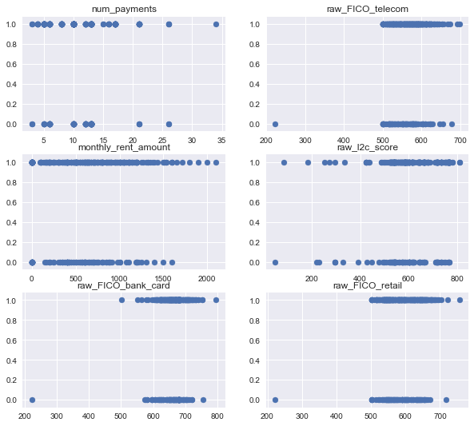

```python
f, axarr = plt.subplots(3, 2, figsize=(10, 9))
funded = trainY.FullyFunded.values
axarr[0, 0].scatter(trainX.num_payments.values, funded)
axarr[0, 0].set_title('num_payments');
axarr[0, 1].scatter(trainX.raw_FICO_telecom.values, funded)
axarr[0, 1].set_title('raw_FICO_telecom');
axarr[1, 0].scatter(trainX.monthly_rent_amount.values, funded)
axarr[1, 0].set_title('monthly_rent_amount');
axarr[1, 1].scatter(trainX['raw_l2c_score'].values, funded)
axarr[1, 1].set_title('raw_l2c_score');
axarr[2, 0].scatter(trainX.raw_FICO_bank_card.values, funded)
axarr[2, 0].set_title('raw_FICO_bank_card');
axarr[2, 1].scatter(trainX.raw_FICO_retail.values, funded)
axarr[2, 1].set_title('raw_FICO_retail');
```

Perhaps people who consistently make payments (num_payments) are more likely to get funding? Could be a contributor to credit history. Wanted to see if there was anything with that, but nothing noticeable showed up in these plots.

#### What about categorizing into levels of FICO score? Using get dummies to assign 0 & 1 to the various levels.

Figuring out how to assign scores by credit level.

Creating tiers based off the original FICO Score

- Exceptional, Very Good, Good, Fair, Very Poor

[figure not shown]

- Exceptional (800-850)
- Very Good (740 to 799)
- Good (670 to 739)
- Fair (580 to 669)
- Very Poor (579 and below)

```python
train_X = trainX.copy() # train_X is the copy dataset!

def fico_telecom_level(df):
    df.loc[df['raw_FICO_telecom'].between(800,850), 'credit_level'] = 'exceptional'
    df.loc[df['raw_FICO_telecom'].between(740,799), 'credit_level'] = 'very good'
    df.loc[df['raw_FICO_telecom'].between(670,739), 'credit_level'] = 'good'
    df.loc[df['raw_FICO_telecom'].between(580,669), 'credit_level'] = 'fair'
    df.loc[df['raw_FICO_telecom'].between(0,579), 'credit_level'] = 'very poor'

    return df

def credit_dummies(df):
    credit_level_dummies = pd.get_dummies(df['credit_level'], prefix='credit')
    df = pd.concat([df, credit_level_dummies], axis=1)
    df.drop('credit_level', axis=1, inplace=True)

    return df

# Dropping features that don't seem to be very predictable
def drop_features(df):
    dropCols = ['bank_routing_number', 'customer_id', 'home_phone_type','status','address_zip',
               'application_when','bank_account_direct_deposit', 'payment_ach',
               'residence_rent_or_own']

    df = df.drop(dropCols, axis = 1, inplace = True)
    return df

# Dropping the credit score columns
def drop_credit(df):
    creditCols = ['raw_l2c_score','raw_FICO_retail', 'raw_FICO_bank_card','raw_FICO_money'] # no raw_FICO_telecom
    df = df.drop(creditCols, axis = 1, inplace = True)
    return df

# Checking to see if training data set copy is same as original
train_X.head()
```

|  | customer_id | status | residence_rent_or_own | monthly_rent_amount | bank_account_direct_deposit | application_when | loan_duration | payment_ach | num_payments | address_zip | bank_routing_number | home_phone_type | monthly_income_amount | raw_l2c_score | raw_FICO_telecom | raw_FICO_retail | raw_FICO_bank_card | raw_FICO_money |
| --- | --- | --- | --- | --- | --- | --- | --- | --- | --- | --- | --- | --- | --- | --- | --- | --- | --- | --- |
| 0 | 9ece67d6c5 | Approved | True | 0 | True | 2010-10-16 14:06:00 | 3 | True | 6 | 84118 | 124001545 | Mobile | 1560 | 614 | 574 | 600 | 656 | 561 |
| 1 | 5c2c402094 | Approved | True | 0 | False | 2010-10-17 13:01:00 | 6 | True | 13 | 84062 | 124000054 | Mobile | 900 | 708 | 501 | 550 | 651 | 563 |
| 2 | e6254cad30 | Approved | True | 620 | True | 2010-10-17 19:52:00 | 6 | True | 13 | 84119 | 124001545 | Mobile | 1434 | 687 | 522 | 561 | 661 | 598 |
| 3 | 49fb42f51d | Approved | False | 785 | False | 2010-10-18 07:05:00 | 4 | True | 8 | 84405 | 124002971 | Mobile | 1600 | 616 | 560 | 552 | 634 | 591 |
| 4 | 195fbe5739 | Approved | True | 700 | True | 2010-10-19 10:58:00 | 4 | True | 8 | 84404 | 124002971 | Mobile | 1360 | 681 | 603 | 654 | 659 | 636 |

```python
# Applying functions to training data set.
drop_features(train_X)
drop_credit(train_X)
train_X = credit_dummies(fico_telecom_level(train_X)) # needs to be assigned to save the dataframe result.

# Check to see if functions transformed dataset successfully.
train_X.head()
```

|  | monthly_rent_amount | loan_duration | num_payments | monthly_income_amount | raw_FICO_telecom | credit_fair | credit_good | credit_very poor |
| --- | --- | --- | --- | --- | --- | --- | --- | --- |
| 0 | 0 | 3 | 6 | 1560 | 574 | 0 | 0 | 1 |
| 1 | 0 | 6 | 13 | 900 | 501 | 0 | 0 | 1 |
| 2 | 620 | 6 | 13 | 1434 | 522 | 0 | 0 | 1 |
| 3 | 785 | 4 | 8 | 1600 | 560 | 0 | 0 | 1 |
| 4 | 700 | 4 | 8 | 1360 | 603 | 1 | 0 | 0 |

Was not able to apply get_dummies inside a function for some reason.  
Going to apply it separately.

### Trying out CART as my first model.

```python
scoring = 'roc_auc'
num_folds = 5
seed = 10
kfold = KFold(n_splits = num_folds, random_state = seed)
y = trainY['FullyFunded'] # Extract target (FullyFunded), not customer_id.

model = DecisionTreeClassifier(random_state = seed)
# Fits the model
model.fit(train_X, y)

scores = cross_val_score(model, train_X, y, cv = kfold, scoring = scoring)
print('CV AUC {}, Avg. AUC {}'.format(scores, scores.mean()))
```

```
CV AUC [ 0.54615385  0.63034188  0.63696716  0.70519713  0.56974922], Avg. AUC 0.6176818462496471
```

Tweaking CART model parameters. Picked these two values for max_depth & min_samples leaf based off the class we looked over the StumbleUpon data.

```python
model = DecisionTreeClassifier(
                max_depth = 4,
                min_samples_leaf = 5, random_state = seed)

model.fit(train_X, y)
scores = cross_val_score(model, train_X, y, cv = kfold, scoring = scoring)
print('CV AUC {}, Avg. AUC {}'.format(scores, scores.mean()))
```

```
CV AUC [ 0.54410256  0.66381766  0.77952481  0.80241935  0.79663009], Avg. AUC 0.7172988969259038
```

Changing the max_depth and min_samples_leaf results in a 10% increase in AUC score.

```python
features = train_X.columns
feature_importances = model.feature_importances_

features_df = pd.DataFrame({'Features': features, 'Importance Score': feature_importances})
features_df.sort_values('Importance Score', inplace=True, ascending=False)

features_df.head(20)
```

|  | Features | Importance Score |
| --- | --- | --- |
| 2 | num_payments | 0.402043 |
| 1 | loan_duration | 0.248258 |
| 4 | raw_FICO_telecom | 0.171630 |
| 0 | monthly_rent_amount | 0.120484 |
| 3 | monthly_income_amount | 0.057585 |
| 5 | credit_fair | 0.000000 |
| 6 | credit_good | 0.000000 |
| 7 | credit_very poor | 0.000000 |

Turns out the indicator columns I created turned out to be nonfactors in the model.  
Although the FICO telecom score is based off the original FICO score with the same score range, it did not contribute anything meaningful to the model.

# Evaluating various models' performances

```python
def model_performance(df):
    scoring = 'roc_auc'
    num_folds = 5
    seed = 10
    kfold = KFold(n_splits = num_folds, random_state = seed)

    results = []
    names = []
    models = []

    # Tweak CART ---- max_depth = 4, min_samples_leaf = 5,
    models.append( ('CART', DecisionTreeClassifier(random_state = seed)) )
    models.append( ('CART v2', DecisionTreeClassifier(random_state = seed, max_depth = 4, min_samples_leaf = 5)) )
    models.append( ('RandomForestClassifier', RandomForestClassifier(random_state = seed)) )
    models.append( ('LogisticRegression', LogisticRegression(random_state = seed)) )
    models.append( ('SVC', SVC(random_state = seed)) )
    models.append( ('GradientBoostingClassifier', GradientBoostingClassifier(random_state = seed)) )
    models.append( ('KNeighborsClassifier', KNeighborsClassifier()) )
    models.append( ('XGBClassifier', xgb.XGBClassifier(seed = seed)) )


    for name, model in models:
        kfold = KFold(n_splits = num_folds, random_state = seed)

        names.append(name)
        model.fit(df, trainY['FullyFunded'])

        scores = cross_val_score(model, df, trainY['FullyFunded'], cv = kfold, scoring = scoring)
        results.append(scores)

        msg = "{}: {} ({})".format(name, scores.mean(), scores.std())
        print(msg)
        print()
    return df
```

```python
model_performance(train_X)
```

```
CART: 0.6176818462496471 (0.05586576194485695)

CART v2: 0.7172988969259038 (0.10026784846312621)

RandomForestClassifier: 0.7136026666627964 (0.06201602954831483)

LogisticRegression: 0.7001591302548761 (0.050607798742858014)

SVC: 0.507339361282107 (0.02479878072069761)

GradientBoostingClassifier: 0.71222368826686 (0.10678444093660712)

KNeighborsClassifier: 0.5684595632821964 (0.05419567007366402)

XGBClassifier: 0.7412029512374759 (0.07457911863731648)
```

[output not shown]

400 rows × 8 columns

```python
scoring = 'roc_auc'
num_folds = 5
seed = 10
kfold = KFold(n_splits = num_folds, random_state = seed)


results = []
names = []
models = []

# CART v2 is the modified CART ---- max_depth = 4, min_samples_leaf = 5,
models.append( ('CART', DecisionTreeClassifier(random_state = seed)) )
models.append( ('CART v2', DecisionTreeClassifier(random_state = seed, max_depth = 4, min_samples_leaf = 5)) )
models.append( ('RandomForestClassifier', RandomForestClassifier(random_state = seed)) )
models.append( ('LogisticRegression', LogisticRegression(random_state = seed)) )
models.append( ('SVC', SVC(random_state = seed)) )
models.append( ('GradientBoostingClassifier', GradientBoostingClassifier(random_state = seed)) )
models.append( ('KNeighborsClassifier', KNeighborsClassifier()) )
models.append( ('XGBClassifier', xgb.XGBClassifier(seed = seed)) )


for name, model in models:
    kfold = KFold(n_splits = num_folds, random_state = seed)

    names.append(name)
    model.fit(train_X, trainY['FullyFunded'])

    scores = cross_val_score(model, train_X, trainY['FullyFunded'], cv = kfold, scoring = scoring)
    results.append(scores)

    msg = "{}: {} ({})".format(name, scores.mean(), scores.std())
    print(msg)
    print()
```

```
CART: 0.6176818462496471 (0.05586576194485695)

CART v2: 0.7172988969259038 (0.10026784846312621)

RandomForestClassifier: 0.7136026666627964 (0.06201602954831483)

LogisticRegression: 0.7001591302548761 (0.050607798742858014)

SVC: 0.507339361282107 (0.02479878072069761)

GradientBoostingClassifier: 0.71222368826686 (0.10678444093660712)

KNeighborsClassifier: 0.5684595632821964 (0.05419567007366402)

XGBClassifier: 0.7412029512374759 (0.07457911863731648)
```

**Refinement Workflow Results - Trial 1**

| Model Description | Local CV (Std Dev) |
| --- | --- |
| **Baseline:** CART | 0.6176 (0.0558) |
| CART v2: Modified parameters | 0.7172 (0.1002) |
| RandomForestClassifier | 0.7136 (0.0620) |
| Logistic Regression | 0.7001 (0.0506) |
| SVC | 0.5073 (0.0247) |
| GradientBoostingClassifier | 0.7122 (0.1067) |
| KNeighborsClassifier | 0.5684 (0.0541) |
| XGBClassifier | 0.7412 (0.0745) |

# Feature Engineering (FE)

- Created a payment_loan_ratio that divides number of payments by loan duration. Perhaps making more payments is indicative of getting a fully funded loan. In a previous scatterplot above, num_payments did not show any correlation with becoming FullyFunded. Although making more payments over the course of a loan could build credit.
- Created an income_rent_difference feature, which shows how much income a person has left over after subtracting their rent payment for the month. People who have more leftover money could be more likely to make their loan payments.
- Created a raw_FICO_telecom to raw_l2c_score ratio since both scores appear to be measures of people who are new to having credit (meaning they have little to no credit history). Settled on using that since raw_l2c_score had a higher max value in the dataset.
  - Used describe() on raw_l2c_score & raw_FICO_telecom to check.

```python
# Feature Engineering (FE)
def first_order_FE(df):
    df["payment_loan_ratio"] = df.apply(payment_loan_ratio, axis=1)
    df["income_rent_difference"] = df.apply(income_rent_difference, axis=1)
    df["telecom_l2c_ratio"] = df.apply(telecom_l2c_ratio, axis=1)
    return df

def payment_loan_ratio(df):
    return df.num_payments / df.loan_duration

def income_rent_difference(df):
    return df.monthly_income_amount - df.monthly_rent_amount

def telecom_l2c_ratio(df):
    return df.raw_FICO_telecom / df.raw_l2c_score
```

One additional method to feature engineer is to predict negative income, see how their monthly income changes from month to month. Data is not available though.

- A shortcoming of income_rent_difference is that we do not know the person's housing situation.
- If they split rent, then it possible to have a higher rent than income.
  - Also the residence_rent_or_own variable is very strange.

## Transforming the dataset using feature engineering.

```python
# Dropping different credit score columns
def drop_credit_FE(df):
    creditCols = ['raw_FICO_retail', 'raw_FICO_bank_card','raw_FICO_money'] # no raw_FICO_telecom or raw_l2c_score
    df = df.drop(creditCols, axis = 1, inplace = True)
    return df
```

```python
train_X2 = trainX.copy()
```

```python
first_order_FE(train_X2)
drop_features(train_X2)
drop_credit_FE(train_X2)
print("Data shape is:",train_X2.shape)
train_X2.head()
```

```
Data shape is: (400, 9)
```

|  | monthly_rent_amount | loan_duration | num_payments | monthly_income_amount | raw_l2c_score | raw_FICO_telecom | payment_loan_ratio | income_rent_difference | telecom_l2c_ratio |
| --- | --- | --- | --- | --- | --- | --- | --- | --- | --- |
| 0 | 0 | 3 | 6 | 1560 | 614 | 574 | 2.000000 | 1560 | 0.934853 |
| 1 | 0 | 6 | 13 | 900 | 708 | 501 | 2.166667 | 900 | 0.707627 |
| 2 | 620 | 6 | 13 | 1434 | 687 | 522 | 2.166667 | 814 | 0.759825 |
| 3 | 785 | 4 | 8 | 1600 | 616 | 560 | 2.000000 | 815 | 0.909091 |
| 4 | 700 | 4 | 8 | 1360 | 681 | 603 | 2.000000 | 660 | 0.885463 |

### Evaluating Model Performances (Test 2)

```python
model_performance(train_X2)
```

```
CART: 0.6394799994283697 (0.060898134262455106)

CART v2: 0.719942773695182 (0.0771449229982496)

RandomForestClassifier: 0.7034117021847415 (0.04230854804834636)

LogisticRegression: 0.6996489925448727 (0.03263125738942909)

SVC: 0.5034252539912918 (0.004231061736970055)

GradientBoostingClassifier: 0.7310378055090209 (0.07371397740202118)

KNeighborsClassifier: 0.5228196330176098 (0.05548563404216828)

XGBClassifier: 0.74950630403108 (0.06869051525966671)
```

[output not shown]

400 rows × 9 columns

| Model Description | Performance 2 - Performance 1 | Change in CV Score |
| --- | --- | --- |
| **Baseline:** CART | 0.6394 - 0.6176 | 0.0218 |
| CART v2: Modified parameters | 0.7199427737 - 0.7172 | 0.0027 |
| RandomForestClassifier | 0.7034117022 - 0.7136 | -0.01018 |
| Logistic Regression | 0.6996489925 - 0.7001 | -0.0004510 |
| SVC | 0.503425254 - 0.5073 | -0.003874 |
| GradientBoostingClassifier | 0.7310378055 - 0.7122 | 0.01883 |
| KNeighborsClassifier | 0.522819633 - 0.5684 | -0.04558 |
| XGBClassifier | 0.749506304 - 0.7412 | 0.008306 |

Overall, only very slight changes in model performances. The baseline model increased by 2%, GradientBoostingClassifier performance improved by 1.88 % while the modified CART (CART v2), and XGBClassifier increased less than a hundredth.

### Next is model tuning!

Decided on tuning GradientBoostingClassifier & XGBClassifier!

### Local CV performance function

```python
def local_cv(model, params, printFeatureImportance=True):
    param_grid = params
    kfold = KFold(n_splits = num_folds, random_state = seed)
    grid = GridSearchCV(estimator=model, param_grid=param_grid, scoring=scoring, cv=kfold)
    grid_result = grid.fit(train_X2, trainY.FullyFunded)

    # Plotting the Feature Importances
    if printFeatureImportance:
        predictors = [x for x in train_X2.columns] # Every x column
        feat_imp = pd.Series(grid_result.best_estimator_.feature_importances_, predictors).sort_values(ascending=False)
        feat_imp.plot(kind='bar', title='Feature Importances')
        plt.ylabel('Feature Importance Score')
        # Dataframe of features
        features_df = pd.DataFrame({'Features': predictors, 'Importance Score': grid_result.best_estimator_.feature_importances_})
        features_df.sort_values('Importance Score', inplace=True, ascending=False)

    print("Best: %f using %s" % (grid_result.best_score_, grid_result.best_params_))
    print()
    for params, mean_score, scores in grid_result.grid_scores_:
        print("%f (%f) with: %r" % (scores.mean(), scores.std(), params))

    return features_df
```

#### GradientBoostingClassifier

```python
GradientBoostingClassifier().get_params().keys()
```

```
dict_keys(['loss', 'min_samples_leaf', 'max_depth', 'min_impurity_split', 'learning_rate', 'init', 'max_features', 'n_estimators', 'verbose', 'min_weight_fraction_leaf', 'random_state', 'max_leaf_nodes', 'subsample', 'min_samples_split', 'criterion', 'warm_start', 'presort'])
```

Using default parameters for GradientBoostingClassifier.

```
Best: 0.731038 using {'min_samples_split': 2, 'min_samples_leaf': 1, 'max_depth': 3, 'learning_rate': 0.1, 'n_estimators': 100}

0.731038 (0.073714) with: {'min_samples_split': 2, 'min_samples_leaf': 1, 'max_depth': 3, 'learning_rate': 0.1, 'n_estimators': 100}
```

|  | Features | Importance Score |
| --- | --- | --- |
| 8 | telecom_l2c_ratio | 0.227898 |
| 6 | payment_loan_ratio | 0.124212 |
| 7 | income_rent_difference | 0.124137 |
| 3 | monthly_income_amount | 0.118957 |
| 0 | monthly_rent_amount | 0.115138 |
| 5 | raw_FICO_telecom | 0.105550 |
| 4 | raw_l2c_score | 0.089340 |
| 2 | num_payments | 0.073142 |
| 1 | loan_duration | 0.021627 |

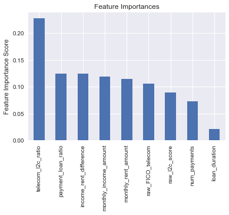

```python
params = {"learning_rate": [0.1],
          "n_estimators": [100],
          "min_samples_split": [2],
          "min_samples_leaf": [1],
          "max_depth": [3]}
local_cv(GradientBoostingClassifier(random_state = seed), params)
```

Using tuned parameters for GradientBoostingClassifier.

```
Best: 0.776827 using {'min_samples_split': 2, 'min_samples_leaf': 7, 'max_depth': 5, 'learning_rate': 0.029999999999999999, 'n_estimators': 150}

0.762412 (0.098131) with: {'min_samples_split': 2, 'min_samples_leaf': 7, 'max_depth': 5, 'learning_rate': 0.01, 'n_estimators': 150}
0.764469 (0.087164) with: {'min_samples_split': 2, 'min_samples_leaf': 7, 'max_depth': 5, 'learning_rate': 0.02, 'n_estimators': 150}
0.776827 (0.084874) with: {'min_samples_split': 2, 'min_samples_leaf': 7, 'max_depth': 5, 'learning_rate': 0.029999999999999999, 'n_estimators': 150}
0.769877 (0.084030) with: {'min_samples_split': 2, 'min_samples_leaf': 7, 'max_depth': 5, 'learning_rate': 0.040000000000000001, 'n_estimators': 150}
0.767794 (0.077459) with: {'min_samples_split': 2, 'min_samples_leaf': 7, 'max_depth': 5, 'learning_rate': 0.050000000000000003, 'n_estimators': 150}
0.767196 (0.084415) with: {'min_samples_split': 2, 'min_samples_leaf': 7, 'max_depth': 5, 'learning_rate': 0.060000000000000005, 'n_estimators': 150}
0.766978 (0.071697) with: {'min_samples_split': 2, 'min_samples_leaf': 7, 'max_depth': 5, 'learning_rate': 0.069999999999999993, 'n_estimators': 150}
0.764184 (0.076127) with: {'min_samples_split': 2, 'min_samples_leaf': 7, 'max_depth': 5, 'learning_rate': 0.080000000000000002, 'n_estimators': 150}
0.763203 (0.079038) with: {'min_samples_split': 2, 'min_samples_leaf': 7, 'max_depth': 5, 'learning_rate': 0.089999999999999997, 'n_estimators': 150}
0.770267 (0.071361) with: {'min_samples_split': 2, 'min_samples_leaf': 7, 'max_depth': 5, 'learning_rate': 0.099999999999999992, 'n_estimators': 150}
```

|  | Features | Importance Score |
| --- | --- | --- |
| 8 | telecom_l2c_ratio | 0.218291 |
| 6 | payment_loan_ratio | 0.157007 |
| 5 | raw_FICO_telecom | 0.113896 |
| 0 | monthly_rent_amount | 0.110226 |
| 2 | num_payments | 0.100089 |
| 7 | income_rent_difference | 0.097350 |
| 3 | monthly_income_amount | 0.096922 |
| 4 | raw_l2c_score | 0.081752 |
| 1 | loan_duration | 0.024466 |

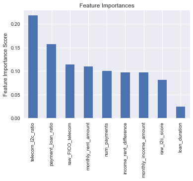

```python
params = {"max_depth": [5],
          "n_estimators": [150],
          "min_samples_split": [2],
          "min_samples_leaf": [7],
          "learning_rate": np.arange(0.01, 0.101, 0.01),}

local_cv(GradientBoostingClassifier(random_state = seed), params)
```

When examining the two feature importances plots, the importance of payment_loan_ratio increases in the tuned model; however, it also brings up the scores of the other features as well so it doesn't rely as much on one feature.

Tweaking the learning rate.  
Found that 0.0409999 --> rounded to 0.041 gives us the best score.

```
Best: 0.779260 using {'min_samples_leaf': 7, 'max_depth': 5, 'learning_rate': 0.041, 'n_estimators': 150, 'max_features': 'auto', 'min_samples_split': 2}

0.779260 (0.072950) with: {'min_samples_leaf': 7, 'max_depth': 5, 'learning_rate': 0.041, 'n_estimators': 150, 'max_features': 'auto', 'min_samples_split': 2}
```

|  | Features | Importance Score |
| --- | --- | --- |
| 8 | telecom_l2c_ratio | 0.197587 |
| 6 | payment_loan_ratio | 0.146133 |
| 0 | monthly_rent_amount | 0.125543 |
| 5 | raw_FICO_telecom | 0.122390 |
| 7 | income_rent_difference | 0.120055 |
| 3 | monthly_income_amount | 0.096514 |
| 4 | raw_l2c_score | 0.080484 |
| 2 | num_payments | 0.073079 |
| 1 | loan_duration | 0.038215 |

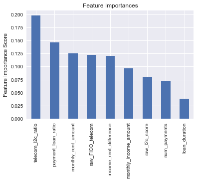

```python
params = {"max_depth": [5],
          "n_estimators": [150],
          "min_samples_split": [2],
          "min_samples_leaf": [7],
          "learning_rate": [0.041],
          "max_features": ['auto']}


local_cv(GradientBoostingClassifier(random_state = seed), params)
```

Tweaking the learning rate gets us even more of an even distribution of importance scores among the features.

```python
xgb.XGBClassifier().get_params().keys()
```

```
dict_keys(['missing', 'learning_rate', 'min_child_weight', 'gamma', 'nthread', 'scale_pos_weight', 'reg_alpha', 'max_delta_step', 'silent', 'objective', 'n_estimators', 'subsample', 'base_score', 'max_depth', 'seed', 'colsample_bytree', 'colsample_bylevel', 'reg_lambda'])
```

```
Best: 0.769292 using {'max_depth': 3, 'min_child_weight': 7, 'n_estimators': 100}

0.769292 (0.037175) with: {'max_depth': 3, 'min_child_weight': 7, 'n_estimators': 100}
```

|  | Features | Importance Score |
| --- | --- | --- |
| 3 | monthly_income_amount | 0.178922 |
| 8 | telecom_l2c_ratio | 0.147059 |
| 5 | raw_FICO_telecom | 0.144608 |
| 7 | income_rent_difference | 0.115196 |
| 0 | monthly_rent_amount | 0.102941 |
| 6 | payment_loan_ratio | 0.098039 |
| 4 | raw_l2c_score | 0.090686 |
| 2 | num_payments | 0.075980 |
| 1 | loan_duration | 0.046569 |

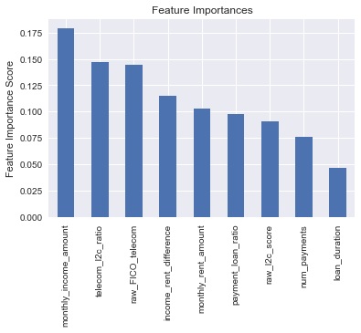

```python
params = {"max_depth": [3],
          "n_estimators": [100],
          "min_child_weight": [7]}

local_cv(xgb.XGBClassifier(seed = seed), params)
```

## Creating ensemble model and submitting prediction

First, the test dataset needs to be transformed. Using the feature engineering functions created to transform the dataset.

```python
first_order_FE(testX)
drop_features(testX)
drop_credit_FE(testX)
print("Data shape is:", testX.shape)
testX.head()
```

```
Data shape is: (247, 9)
```

|  | monthly_rent_amount | loan_duration | num_payments | monthly_income_amount | raw_l2c_score | raw_FICO_telecom | payment_loan_ratio | income_rent_difference | telecom_l2c_ratio |
| --- | --- | --- | --- | --- | --- | --- | --- | --- | --- |
| 0 | 750 | 8 | 13 | 3500 | 718 | 594 | 1.625 | 2750 | 0.827298 |
| 1 | 525 | 5 | 10 | 670 | 719 | 571 | 2.000 | 145 | 0.794159 |
| 2 | 575 | 3 | 6 | 2200 | 719 | 647 | 2.000 | 1625 | 0.899861 |
| 3 | 400 | 8 | 6 | 800 | 616 | 526 | 0.750 | 400 | 0.853896 |
| 4 | 795 | 8 | 6 | 4141 | 705 | 513 | 0.750 | 3346 | 0.727660 |

```python
# Create the sub models. Using XGBClassifier & GradientBoostingClassifier
estimators = []

model1 = xgb.XGBClassifier(n_estimators = 100, min_child_weight = 7, max_depth = 3)
estimators.append(('XGBClassifier', model1))

model2 = GradientBoostingClassifier(max_depth = 5, n_estimators = 150,
                                    min_samples_split = 2,
                                    min_samples_leaf = 7,
                                    learning_rate = 0.041,
                                    max_features = 'auto')
estimators.append(('GradientBoostingClassifier', model2))


# Creating ensemble model
ensemble = VotingClassifier(estimators, voting='soft')
results = cross_val_score(ensemble, train_X2, trainY.FullyFunded, cv = kfold)

# Printing results
print("CV Scores: {} // Mean Score: {} // Std Dev: {}".format(results, results.mean(), results.std()))
print()

# Fitting model then making a prediction
ensemble_result = ensemble.fit(train_X2, trainY.FullyFunded)
ensemble_preds = ensemble_result.predict(testX)

print("Estimators variable:\n", estimators)
print()
print(ensemble)
```

```
CV Scores: [ 0.8     0.7375  0.8125  0.825   0.825 ] // Mean Score: 0.8 // Std Dev: 0.03259601202601321

Estimators variable:
 [('XGBClassifier', XGBClassifier(base_score=0.5, colsample_bylevel=1, colsample_bytree=1,
       gamma=0, learning_rate=0.1, max_delta_step=0, max_depth=3,
       min_child_weight=7, missing=None, n_estimators=100, nthread=-1,
       objective='binary:logistic', reg_alpha=0, reg_lambda=1,
       scale_pos_weight=1, seed=0, silent=True, subsample=1)), ('GradientBoostingClassifier', GradientBoostingClassifier(criterion='friedman_mse', init=None,
              learning_rate=0.041, loss='deviance', max_depth=5,
              max_features='auto', max_leaf_nodes=None,
              min_impurity_split=1e-07, min_samples_leaf=7,
              min_samples_split=2, min_weight_fraction_leaf=0.0,
              n_estimators=150, presort='auto', random_state=None,
              subsample=1.0, verbose=0, warm_start=False))]

VotingClassifier(estimators=[('XGBClassifier', XGBClassifier(base_score=0.5, colsample_bylevel=1, colsample_bytree=1,
       gamma=0, learning_rate=0.1, max_delta_step=0, max_depth=3,
       min_child_weight=7, missing=None, n_estimators=100, nthread=-1,
       objective='binary:logistic', reg_alpha=0, reg_lambda=1,...=150, presort='auto', random_state=None,
              subsample=1.0, verbose=0, warm_start=False))],
         n_jobs=1, voting='soft', weights=None)
```

# Submission to CSV file

```python
submission = pd.DataFrame({"customerId": testY.customer_id, "FullyFunded": ensemble_preds})
submission.to_csv("HW3_Final_Predictions.csv", index = False)
```

# Final Workflow Results

**Workflow Results - Trial 1: One Hot Encoded Credit Score Levels**

| Model Description | Local CV (Std Dev) |
| --- | --- |
| **Baseline:** CART | 0.6176 (0.0558) |
| CART v2: Modified parameters | 0.7172 (0.1002) |
| RandomForestClassifier | 0.7136 (0.0620) |
| Logistic Regression | 0.7001 (0.0506) |
| SVC | 0.5073 (0.0247) |
| GradientBoostingClassifier | 0.7122 (0.1067) |
| KNeighborsClassifier | 0.5684 (0.0541) |
| XGBClassifier | 0.7412 (0.0745) |

**Workflow Results - Trial 2: With Feature Engineering**

| Model Description | Performance 2 - Performance 1 | Change in CV Score |
| --- | --- | --- |
| **Baseline:** CART | 0.6394 - 0.6176 | 0.0218 |
| CART v2: Modified parameters | 0.7199427737 - 0.7172 | 0.0027 |
| RandomForestClassifier | 0.7034117022 - 0.7136 | -0.01018 |
| Logistic Regression | 0.6996489925 - 0.7001 | -0.0004510 |
| SVC | 0.503425254 - 0.5073 | -0.003874 |
| GradientBoostingClassifier | 0.7310378055 - 0.7122 | 0.01883 |
| KNeighborsClassifier | 0.522819633 - 0.5684 | -0.04558 |
| XGBClassifier | 0.749506304 - 0.7412 | 0.008306 |

**Workflow Results - Trial 3: Using GridSearch and Ensemble (w/ Feature Engineering)**

[output not shown]